# Отчет о прохождении внешнего курса

1 этап

Маркеш В.Н Грасимилде.

Российский университет дружбы народов, Москва, Россия

# Информация

## Докладчик

- Маркеш Виейра Нанке Грасимилде
- студент НКАбд-05-25
- Российский университет дружбы народов *[1032255356@rudn.ru]

# Цель работы

Пройти 1 этап курса ‘Введение в Linux’ на платформе Stepik. Ознакомиться с функционалом операционной системы Linux.

# Задание

Просмотреть обучающие видео и на основе полученной информации пройти тестовые задания.

# Выполнение внешнего курса

Курс действительно называется “Введение в Linux”, поэтому с этим вопросом проблем не возникло.

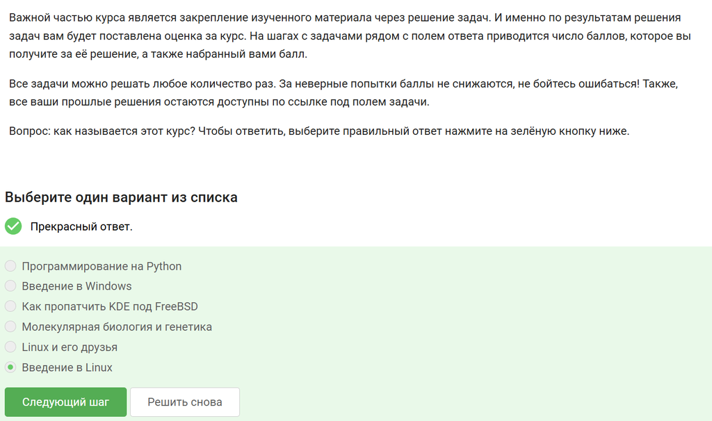

# Выполнение внешнего курса

Прочитав критерии прохождения курса, я отметила необходимые утверждения.

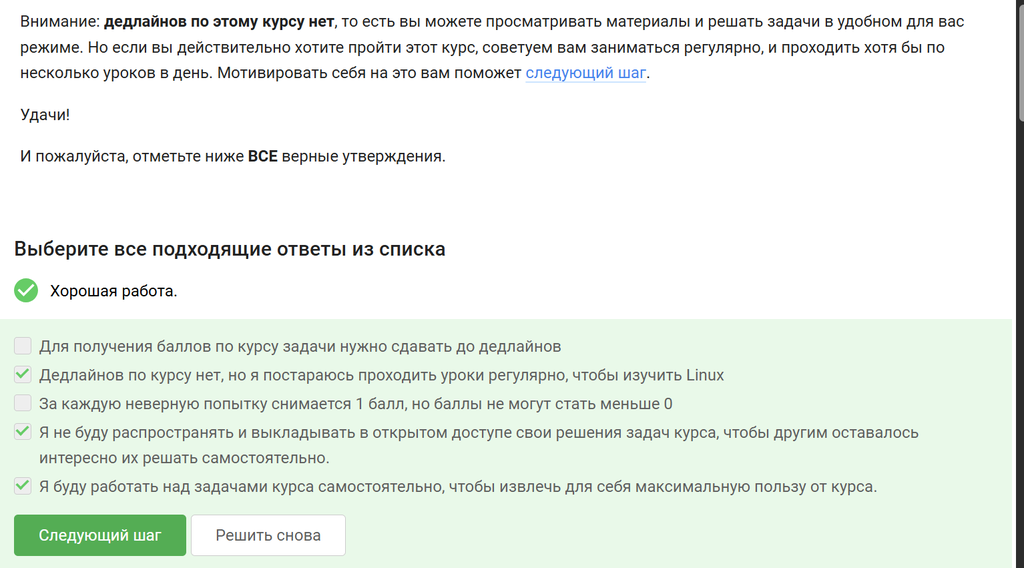

# Выполнение внешнего курса

Стандартная операционная система, предлагаемая большей частью магазинов - windows, именно она стоит у меня на основном компьютере.

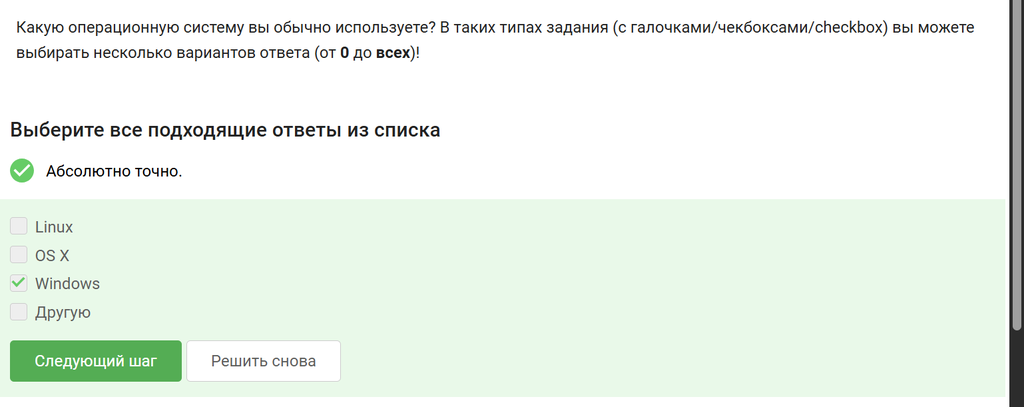

# Выполнение внешнего курса

На свой компьютер мы устанавливали специальную программу VirtualBox, которая нужна для подключения одной операционной на другой.

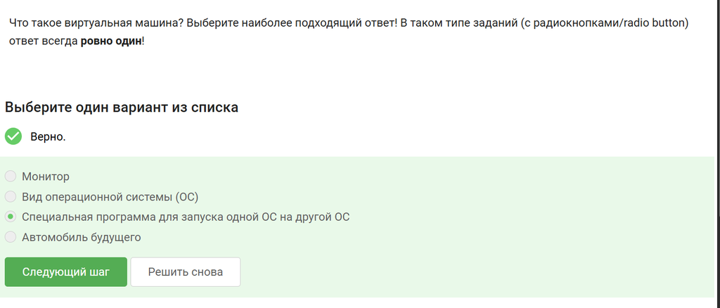

# Выполнение внешнего курса

Да, моя виртуальная машина хорошо работает, и у меня получилось запустить с неё Линукс.

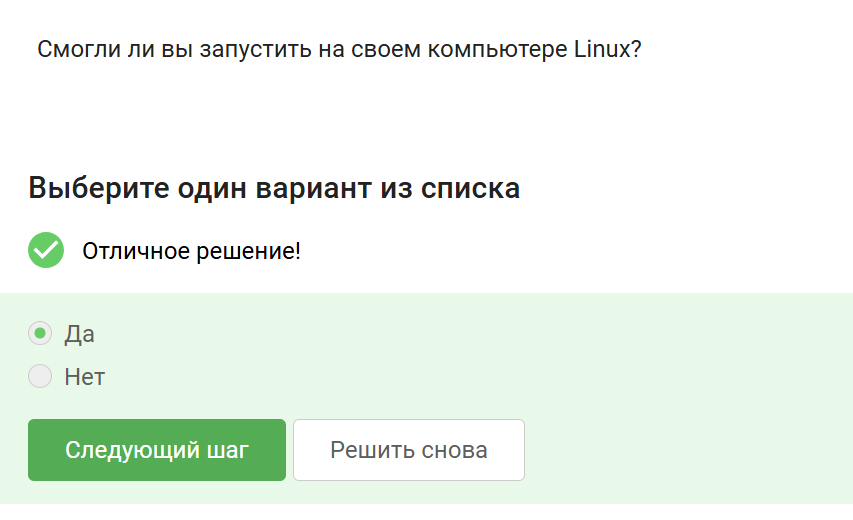

# Выполнение внешнего курса

Я создала документ, и перед сохранением выбрала нужный формат, а после я ег прикрепила к курсу.

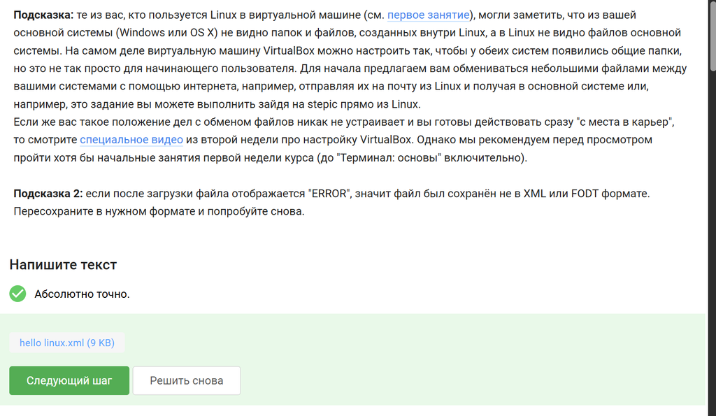

# Выполнение внешнего курса

deb - формат пакетов ОС проекта Debian. Используется также их производными, например Ubuntu, Knoppix и другими

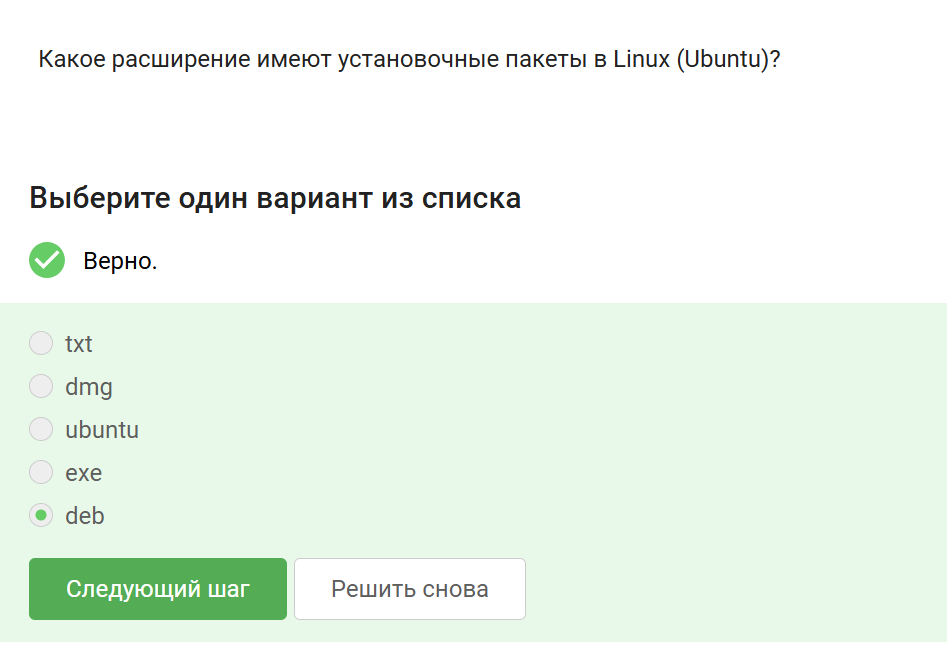

# Выполнение внешнего курса

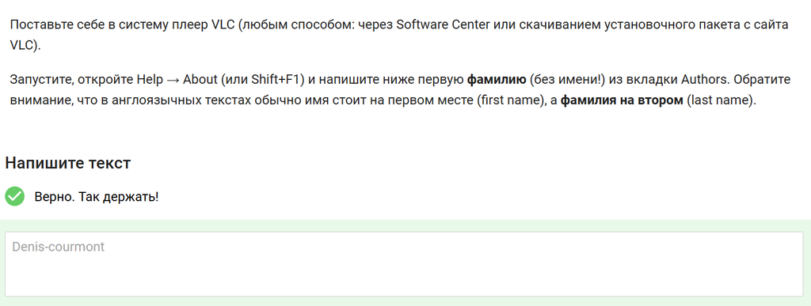

# Выполнение внешнего курса

Менеджер обновлений - программа для обновления установленного ПО в дистрибутивах линукса, основанных на Debian или использующих систему управления пакетами APT. Менеджер обновлений устанавливает обновления безопасности или просто улучшающие функциональность программы.

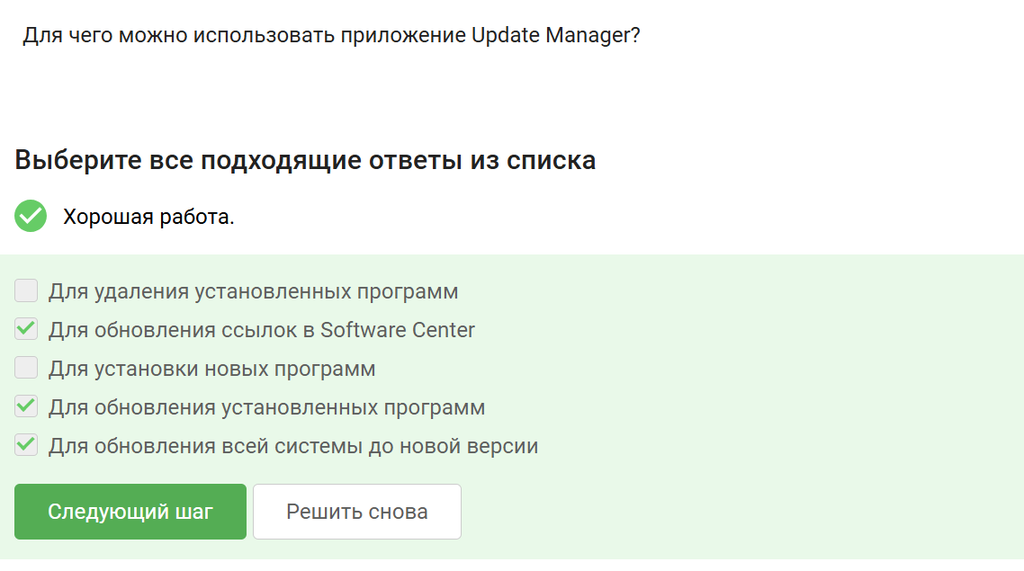

# Выполнение внешнего курса

Ассоль - женское русское имя, термин - определение, консоль и терминал - синонимы для командной строки.

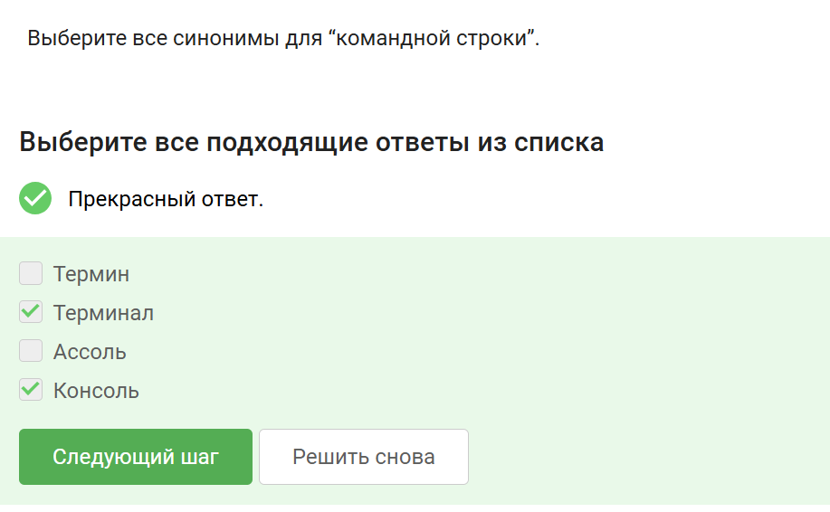

# Выполнение внешнего курса

Интерфейс командной строки линукс является регистрозависимым.

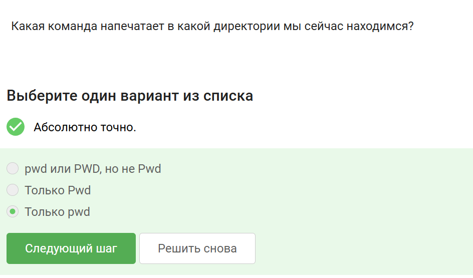

# Выполнение внешнего курса

Интерфейс командной строки линукс является регистрозависимым, поэтому не все варианты подходят

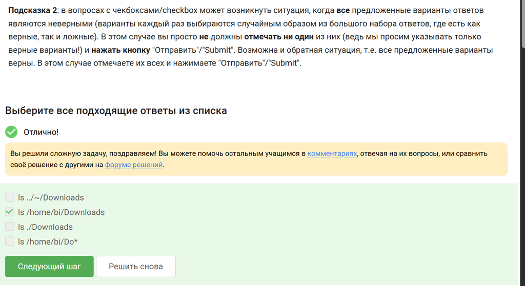

# Выполнение внешнего курса

rm -r - удаление директории и рекуррентное удаление всех файлов, которые в ней находились.

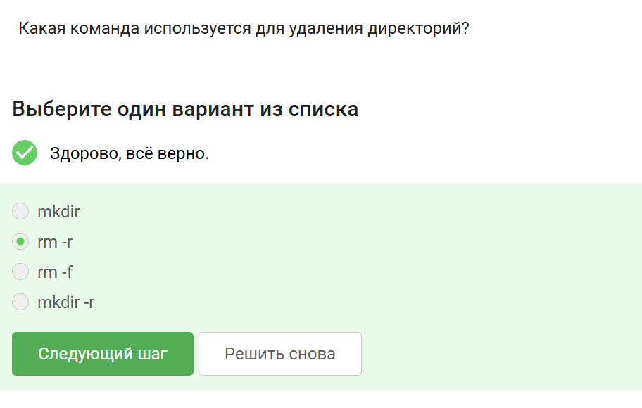

# Выполнение внешнего курса

Это я проверила эмпирическим путём, что видно в ходе скринкаста.

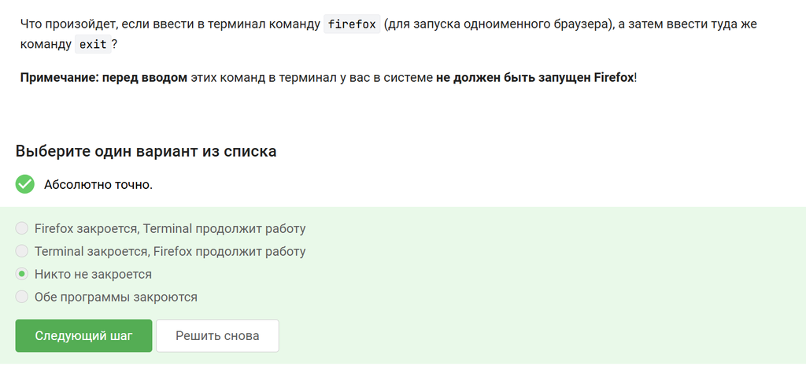

# Выполнение внешнего курса

Это запуск программы в фоновом режиме.

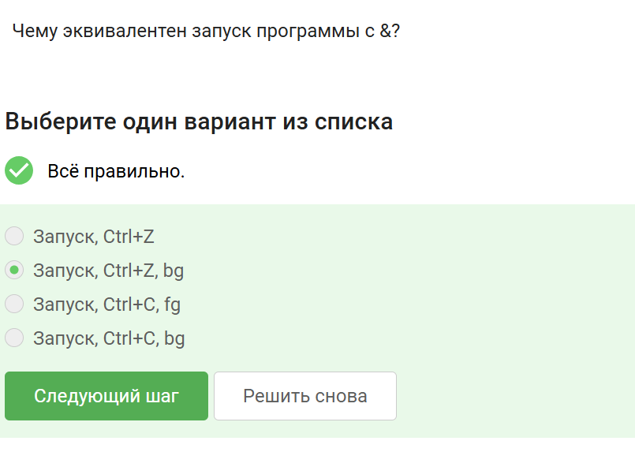

# Выполнение внешнего курса

Здесь видно выполнение команды.

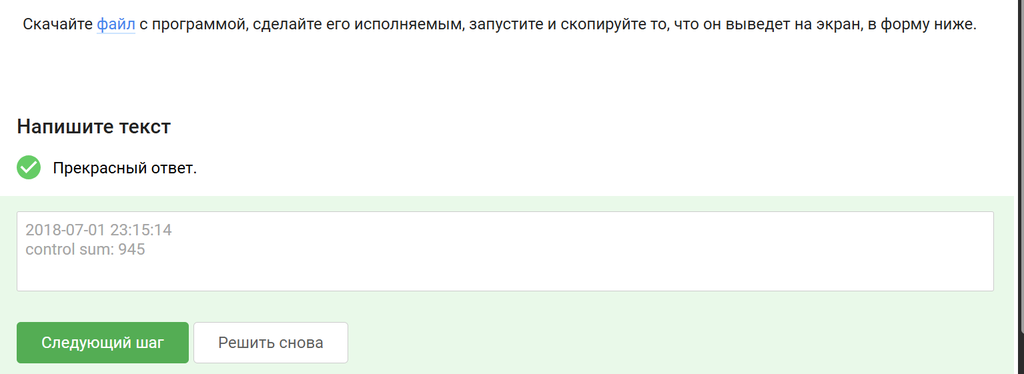

# Выполнение внешнего курса

Автоматически поток ошибок выводится на экран - это видно, например, в ходе выполненных лабораторных. В файл будет поток выводиться, если его перенаправить.

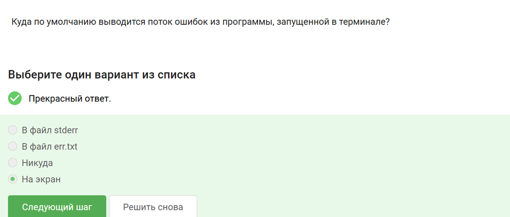

# Выполнение внешнего курса

gzip (сокращение от GNU Zip) — утилита сжатия и восстановления (декомпрессии) файлов, использующая алгоритм Deflate.

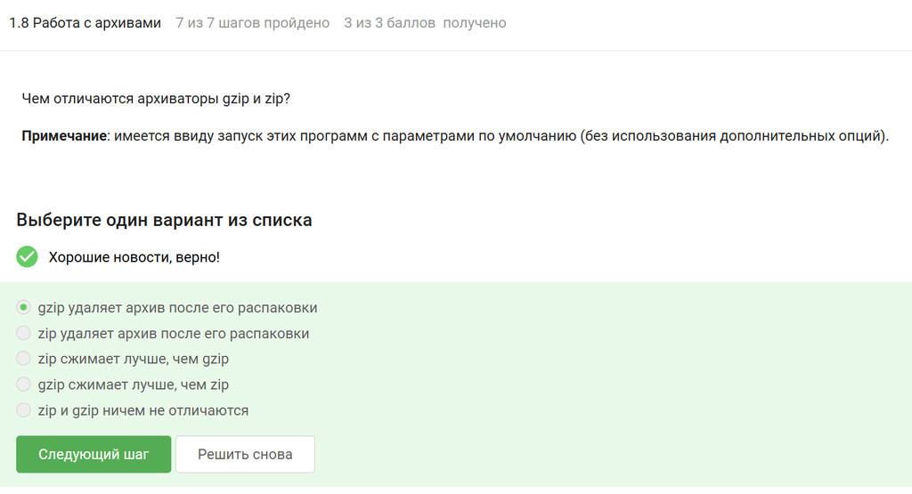

# Выполнение внешнего курса

c - архиватор

j - указатель на тип архиватора bzip

f - потому что создаем архив в файловой системе

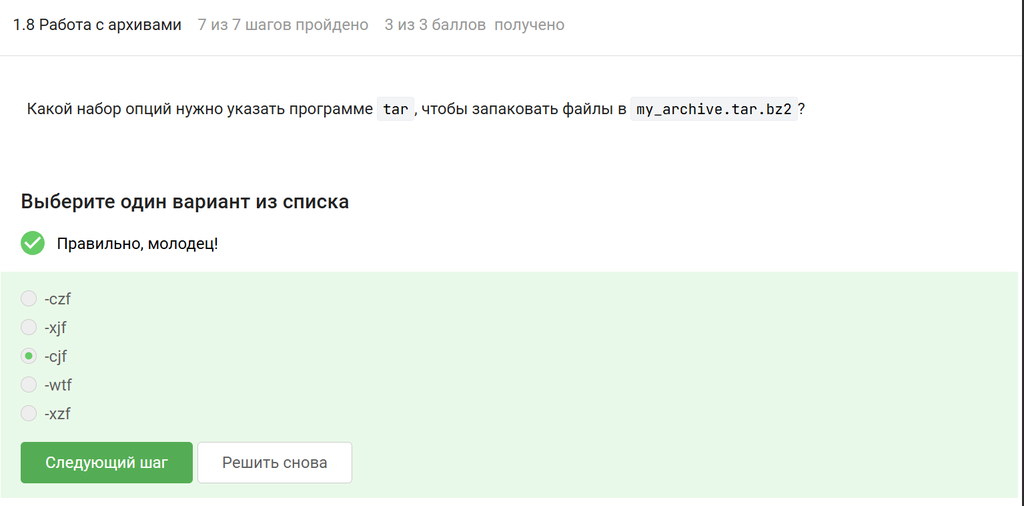

# Выполнение внешнего курса

`?` = один символ

`alexey` = маленькая буква

И файл должен быть `jpeg`, а не `jpg`

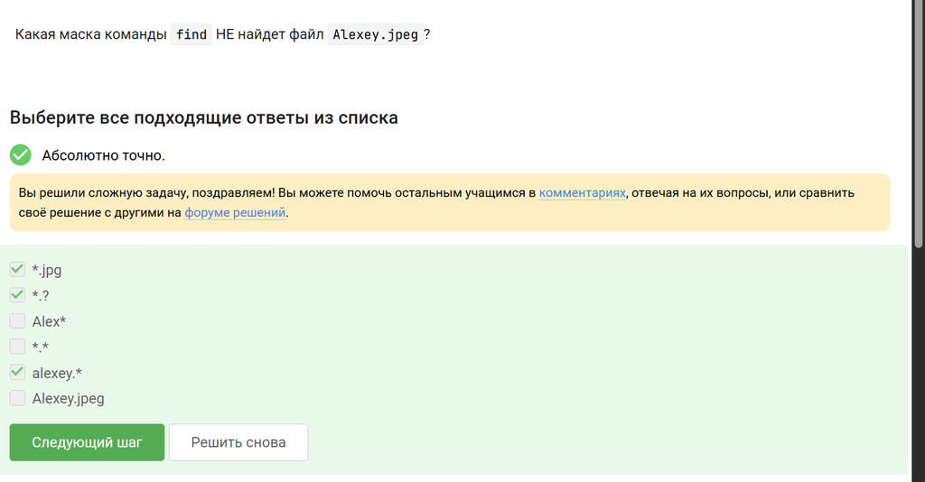

# Выполнение внешнего курса

Регистр - маленькая буква, слово - `world`, а не `word`

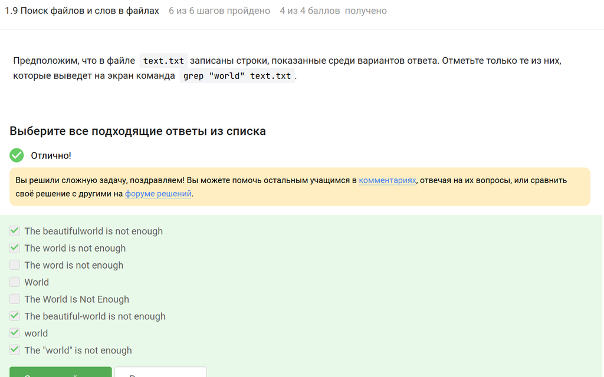

# Выполнение внешнего курса

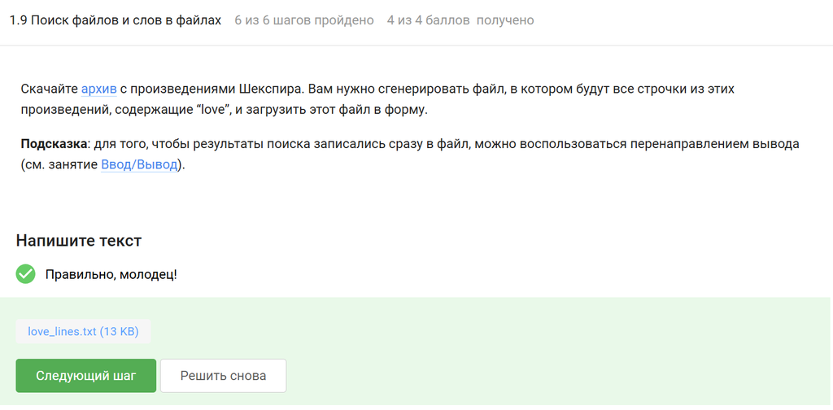

# Выводы

Я прошла 1 этап курса ‘Введение в Linux’ на платформе Stepik и ознакомилась с функционалом операционной системы Linux.